# Lab 4 Solutions

## Exercise 1

```r
pines_new <- Pines %>%
  drop_na()
```

## Exercise 2

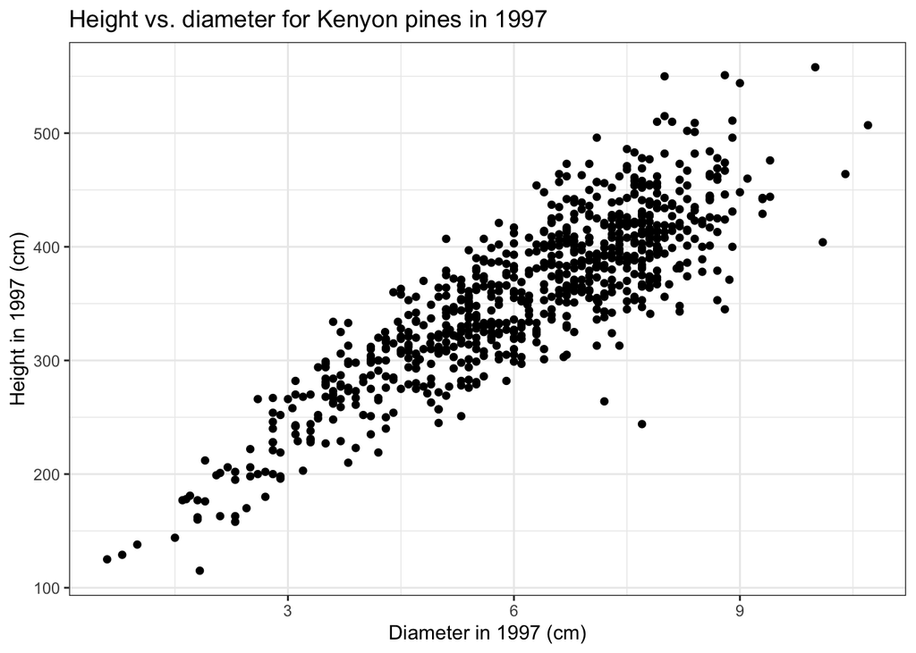

```r
pines_new %>%
  ggplot(aes(x = Diam97,
             y = Hgt97)) +
  geom_point() +
  labs(x = "Diameter in 1997 (cm)",
       y = "Height in 1997 (cm)",
       title = "Height vs. diameter for Kenyon pines in 1997") +
  theme_bw()
```

```r
pines_new %>%
  summarize(r = cor(Diam97, Hgt97))
```

```
##           r
## 1 0.8632523
```

There appears to be a strong, positive, reasonably linear association between diameter and height, with a sample correlation of 0.86.

## Exercise 3

```r
pines_lm <- lm(Hgt97 ~ Diam97, data = pines_new)
```

## Exercise 4

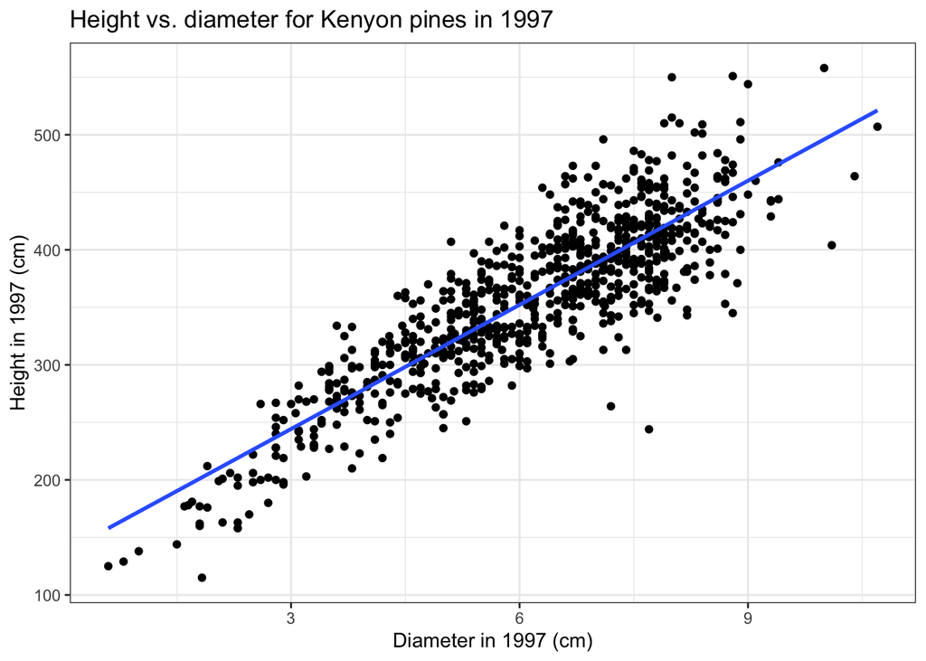

```r
pines_new %>%
  ggplot(aes(x = Diam97,
             y = Hgt97)) +
  geom_point() +
  geom_smooth(method = "lm", se = F) +
  labs(x = "Diameter in 1997 (cm)",
       y = "Height in 1997 (cm)",
       title = "Height vs. diameter for Kenyon pines in 1997") +
  theme_bw()
```

```r
summary(pines_lm)
```

```
##
## Call:
## lm(formula = Hgt97 ~ Diam97, data = pines_new)
##
## Residuals:
##      Min       1Q   Median       3Q      Max
## -169.310  -23.934   -1.108   23.496  125.901
##
## Coefficients:
##             Estimate Std. Error t value Pr(>|t|)
## (Intercept) 136.3829     4.8103   28.35   <2e-16 ***
## Diam97       35.9645     0.7549   47.64   <2e-16 ***
## ---
## Signif. codes:  0 '***' 0.001 '**' 0.01 '*' 0.05 '.' 0.1 ' ' 1
##
## Residual standard error: 36.47 on 776 degrees of freedom
## Multiple R-squared:  0.7452, Adjusted R-squared:  0.7449
## F-statistic:  2270 on 1 and 776 DF,  p-value: < 2.2e-16
```

$\widehat{\text{height}} = 136.38 + 35.96 \ \text{diameter}$

## Exercise 5

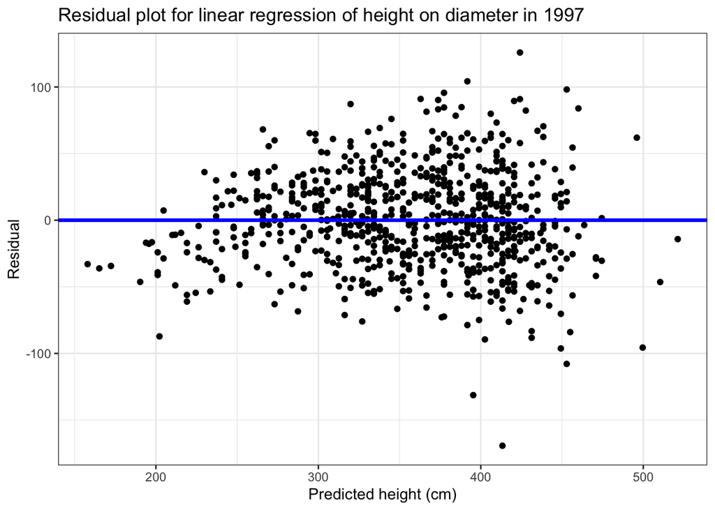

```r
pines_new %>%
  mutate(resids = residuals(pines_lm),
         yhat = predict(pines_lm)) %>%
  ggplot(aes(x = yhat,
             y = resids)) +
  geom_point() +
  geom_abline(slope = 0, intercept = 0,
              lwd = 1.2, color="blue") +
  labs(x = "Predicted height (cm)",
       y = "Residual",
       title = "Residual plot for linear regression of height on diameter in 1997") +
  theme_bw()
```

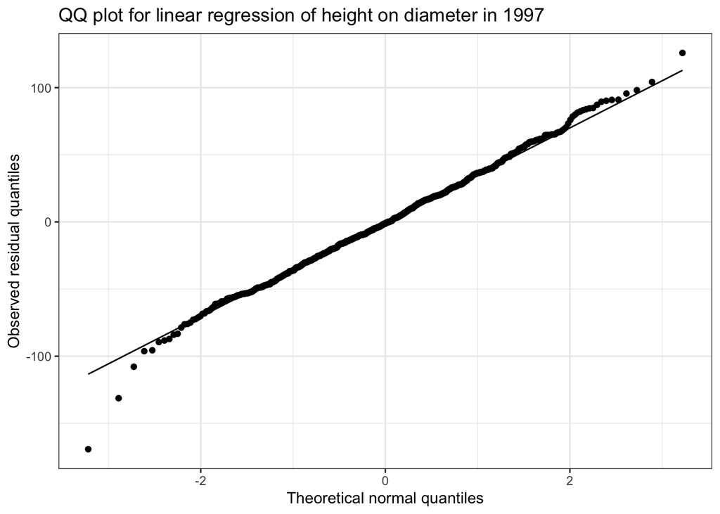

```r
pines_new %>%
  mutate(resids = residuals(pines_lm)) %>%
  ggplot(aes(sample = resids)) +
  geom_qq() +
  geom_qq_line() +
  labs(x = "Theoretical normal quantiles",
       y = "Observed residual quantiles",
       title = "QQ plot for linear regression of height on diameter in 1997") +
  theme_bw()
```

## Exercise 6

**Note: while there might be slight violations of shape and constant variance here, they probably aren’t big enough to really matter. I think inference with this model would still be reasonable, even if there are some slight violations.**

## Exercise 7

```r
summary(pines_lm)
```

```
##
## Call:
## lm(formula = Hgt97 ~ Diam97, data = pines_new)
##
## Residuals:
##      Min       1Q   Median       3Q      Max
## -169.310  -23.934   -1.108   23.496  125.901
##
## Coefficients:
##             Estimate Std. Error t value Pr(>|t|)
## (Intercept) 136.3829     4.8103   28.35   <2e-16 ***
## Diam97       35.9645     0.7549   47.64   <2e-16 ***
## ---
## Signif. codes:  0 '***' 0.001 '**' 0.01 '*' 0.05 '.' 0.1 ' ' 1
##
## Residual standard error: 36.47 on 776 degrees of freedom
## Multiple R-squared:  0.7452, Adjusted R-squared:  0.7449
## F-statistic:  2270 on 1 and 776 DF,  p-value: < 2.2e-16
```

## Exercise 8

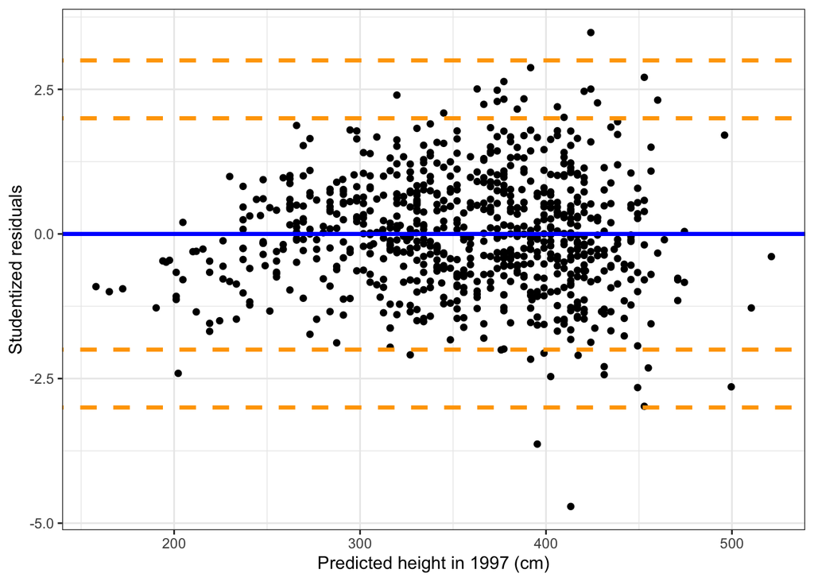

```r
pines_new %>%
  mutate(studentized_resids = rstudent(pines_lm),
         yhat = predict(pines_lm)) %>%
  ggplot(aes(x = yhat, y = studentized_resids)) +
  geom_point() +
  geom_abline(slope = 0, intercept = 0,
              color = "blue", lwd=1.2) +
  geom_abline(slope = 0, intercept = c(-3, -2, 2, 3),
              color = "orange", lty = 2, lwd=1.2) +
  labs(x = "Predicted height in 1997 (cm)",
       y = "Studentized residuals") +
  theme_bw()
```

There are a few potential outliers, with studentized residuals > 3 or < -3. In particular, there is one point with a studentized residual close to -5.

## Exercise 9

```r
pines_new_2 <- pines_new %>%
  mutate(studentized_resids = rstudent(pines_lm)) %>%
  filter(studentized_resids != min(studentized_resids))

pines_lm_2 <- lm(Hgt97 ~ Diam97, data = pines_new_2)
pines_lm_2
```

```
##
## Call:
## lm(formula = Hgt97 ~ Diam97, data = pines_new_2)
##
## Coefficients:
## (Intercept)       Diam97
##      135.90        36.08
```

Removing the potential outlier hardly changes the fit at all – the estimated slope and intercept are almost identical to what they were before.

## Exercise 10

Here’s an example with a square root transformation of both the predictor and the response:

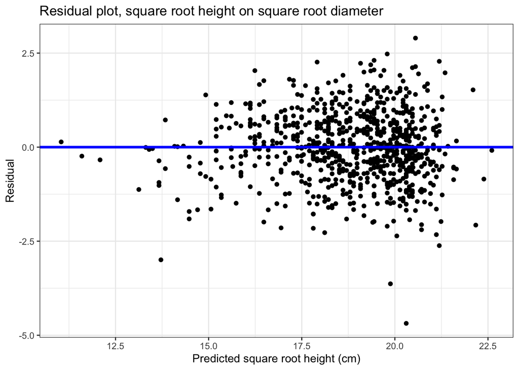

```r
pines_transformed <- pines_new %>%
  mutate(sqrt_height = sqrt(Hgt97),
         sqrt_diameter = sqrt(Diam97))

pines_transformed_lm <- lm(sqrt_height ~ sqrt_diameter,
                           data = pines_transformed)

pines_transformed %>%
  mutate(resids = residuals(pines_transformed_lm),
         yhat = predict(pines_transformed_lm)) %>%
  ggplot(aes(x = yhat,
             y = resids)) +
  geom_point() +
  geom_abline(slope = 0, intercept = 0,
              lwd = 1.2, color="blue") +
  labs(x = "Predicted square root height (cm)",
       y = "Residual",
       title = "Residual plot, square root height on square root diameter") +
  theme_bw()
```

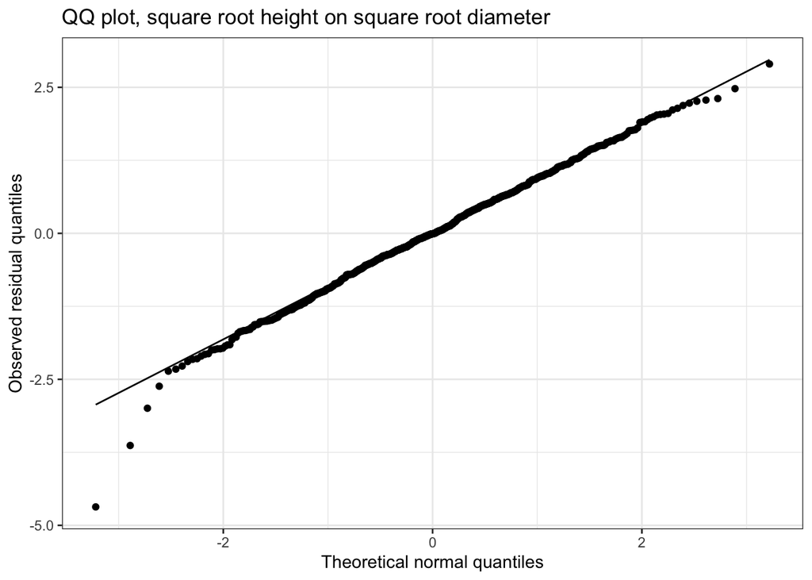

```r
pines_transformed %>%
  mutate(resids = residuals(pines_transformed_lm)) %>%
  ggplot(aes(sample = resids)) +
  geom_qq() +
  geom_qq_line() +
  labs(x = "Theoretical normal quantiles",
       y = "Observed residual quantiles",
       title = "QQ plot, square root height on square root diameter") +
  theme_bw()
```

## Exercise 11

Many transformations, including this one, don’t change the diagnostic plots all that much. And the initial linear model is probably good enough that transformations aren’t really necessary anyway.